# Time series modelling for crop yield

### Objective:

To predict crop yield for year 2024 based on data from 1947 to 2023

### Importing Libraries

```r
library(forecast)
library(urca)    #for DF test
```

### Importing the data

```r
cropdata<-read.csv("CROP DATA.csv",header=T)
head(cropdata)
```

```
  Year Quarter CROPYIELD
1 1947       1  2182.681
2 1947       2  2176.892
3 1947       3  2172.432
4 1947       4  2206.452
5 1948       1  2239.682
6 1948       2  2276.690
```

### Converting the Quaterly data to Yearly

```r
cropdata_yearly<-aggregate(CROPYIELD~Year, data=cropdata, FUN = sum)
```

### Define time series using ts function

```r
cropseries<-ts(cropdata_yearly$CROPYIELD,start=1947,end=2023)
```

### Step One: Stationarity Checking

#### a) Plot Time Series

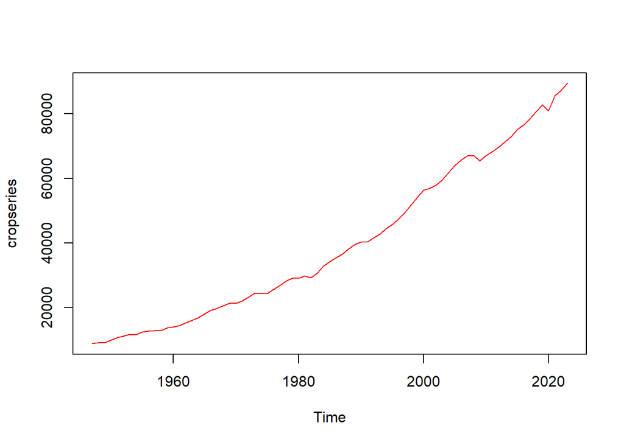

```r
plot(cropseries,col="red")
```

**Inference**: It’s a non-stationary time series.

#### b) Correlogram

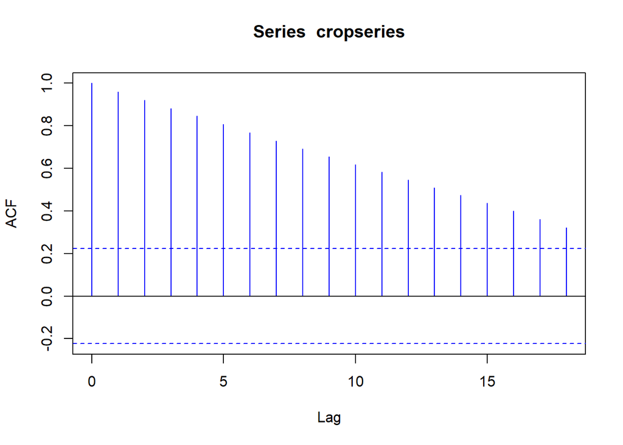

```r
acf(cropseries,col="blue")
```

**Inference**: We can see a very slow decay. Hence, it’s a sign of non-stationary

#### c) Dickey Fuller Test

```r
df<-ur.df(cropseries,lag=0)
summary(df)
```

```
###############################################
# Augmented Dickey-Fuller Test Unit Root Test #
###############################################

Test regression none


Call:
lm(formula = z.diff ~ z.lag.1 - 1)

Residuals:
    Min      1Q  Median      3Q     Max
-3852.5  -220.7   192.8   568.3  2718.8

Coefficients:
        Estimate Std. Error t value Pr(>|t|)
z.lag.1 0.024411   0.002221   10.99   <2e-16 ***
---
Signif. codes:  0 '***' 0.001 '**' 0.01 '*' 0.05 '.' 0.1 ' ' 1

Residual standard error: 886.6 on 75 degrees of freedom
Multiple R-squared:  0.617, Adjusted R-squared:  0.6119
F-statistic: 120.8 on 1 and 75 DF,  p-value: < 2.2e-16


Value of test-statistic is: 10.9911

Critical values for test statistics:
     1pct  5pct 10pct
tau1 -2.6 -1.95 -1.61
```

**Inference**: The value of the test statistic is: 10.9911. Which is greater than 5% critical value. Hence, Time series is non-stationary.

**How many times Should time Series Be differenced to make it Stationary?**

```r
ndiffs(cropseries)
```

```
[1] 2
```

```r
cropdiff2<-diff(cropseries,differences=2)
```

Timeseries should be differenced 2 times to achieve stationarity.

#### Checking whether stationarity is achieved after differencing

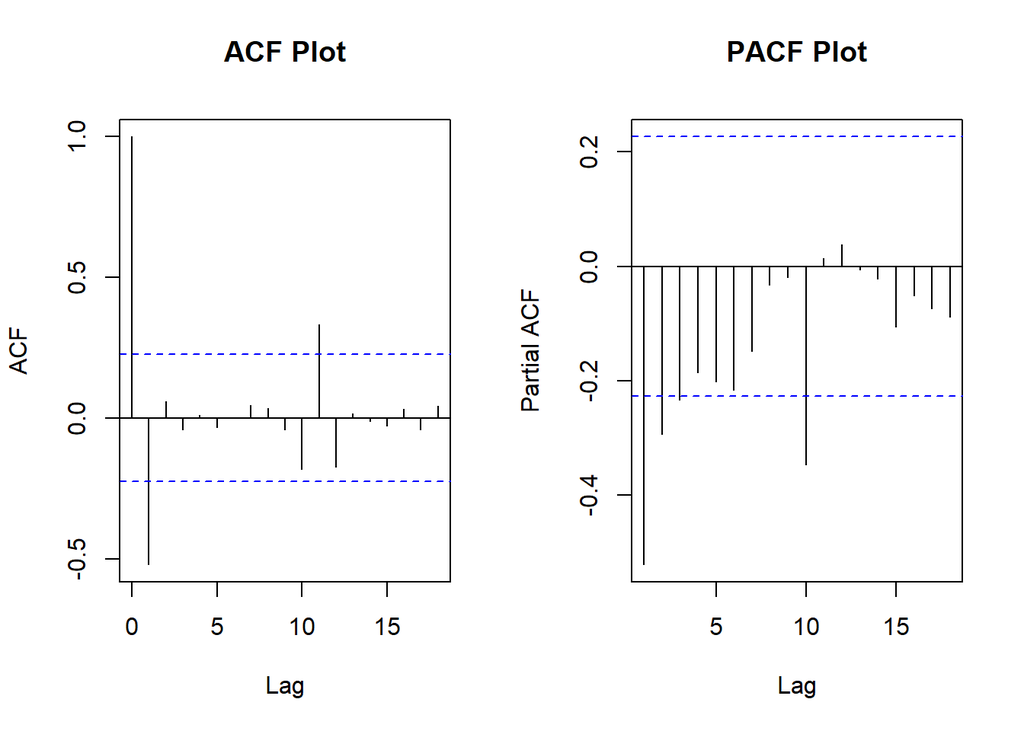

```r
# Plot ACF and PACF side by side
par(mfrow = c(1, 2))
acf_plot <- acf(cropdiff2, main = "ACF Plot")
pacf_plot <- pacf(cropdiff2, main = "PACF Plot")
```

```r
par(mfrow = c(1, 1))  # Reset the plotting layout
```

Although, Indicative Statistical Model indicates (1,2,1), we will be considering p=2 and q=2 for auto.arima

```r
df_test<-ur.df(cropdiff2,lag=0) # Dickey Fuller Test on Differenced data
summary(df_test)
```

```
###############################################
# Augmented Dickey-Fuller Test Unit Root Test #
###############################################

Test regression none


Call:
lm(formula = z.diff ~ z.lag.1 - 1)

Residuals:
    Min      1Q  Median      3Q     Max
-3999.3  -439.3   122.1   478.0  4531.4

Coefficients:
        Estimate Std. Error t value Pr(>|t|)
z.lag.1 -1.52163    0.09994  -15.23   <2e-16 ***
---
Signif. codes:  0 '***' 0.001 '**' 0.01 '*' 0.05 '.' 0.1 ' ' 1

Residual standard error: 1062 on 73 degrees of freedom
Multiple R-squared:  0.7605,    Adjusted R-squared:  0.7572
F-statistic: 231.8 on 1 and 73 DF,  p-value: < 2.2e-16


Value of test-statistic is: -15.2256

Critical values for test statistics:
     1pct  5pct 10pct
tau1 -2.6 -1.95 -1.61
```

**Inference**: The value of the test statistic is: -15.2256. Which is less than 5% critical value. Hence, Stationarity is achieved with second order difference.

### Step Two and Three: Model Identification and Parameter Estimation

ARIMA Model

```r
crop_model<-auto.arima(cropseries,d=2,max.p=2,max.q=2,trace=TRUE,ic="aic")
```

```
 ARIMA(2,2,2)                    : 1244.935
 ARIMA(0,2,0)                    : 1281.959
 ARIMA(1,2,0)                    : 1260.488
 ARIMA(0,2,1)                    : 1239.208
 ARIMA(1,2,1)                    : 1241.172
 ARIMA(0,2,2)                    : 1241.173
 ARIMA(1,2,2)                    : 1243.015

 Best model: ARIMA(0,2,1)
```

```r
coef(crop_model)
```

```
       ma1
-0.8961226
```

```r
AIC(crop_model)
```

```
[1] 1239.208
```

Smaller the AIC value, better is the model. auto.arima tries out various combinations of AR and MA terms to arrive at final model. Best model: ARIMA(0,2,1)

### Step Four: Diagnostic Checking

```r
resi<-residuals(crop_model)
Box.test(resi)
```

```
    Box-Pierce test

data:  resi
X-squared = 0.30544, df = 1, p-value = 0.5805
```

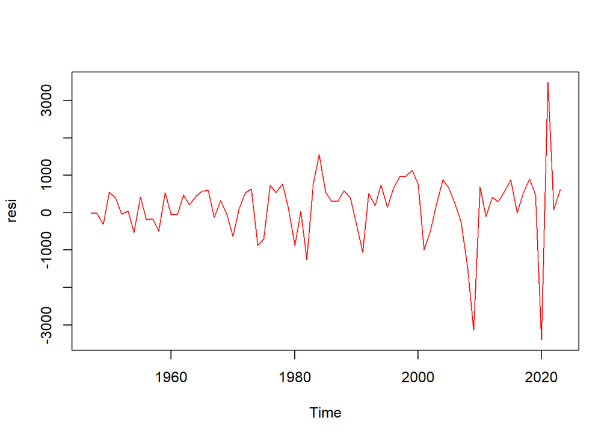

```r
plot(resi,col="red")
```

Inference: with a p-value of 0.5805, it seems that there is not enough evidence to reject the null hypothesis at the 0.05 significance level. Therefore, there is no significant autocorrelation in the residuals.

### Step Five: Forecasting

Making prediction for 1 year

```r
predict(crop_model,n.ahead=1)
```

```
$pred
Time Series:
Start = 2024
End = 2024
Frequency = 1
[1] 91144.54

$se
Time Series:
Start = 2024
End = 2024
Frequency = 1
[1] 908.3818
```

**Inference**: Prediction for CropYeild 2024 is **91144.54**

**Note:** Since the quarterly data is converted into yearly data, seasonality is not considered in the model ( to be considered in SARIMA)